# An ARIMA model of the U.S. 30 year mortgage rate

2025-10-07

On September 17th, the Federal Reserve announced a quarter point cut in the target range of the federal funds rate or, as most news outlets reported it, a 0.25% cut in interest rates. It is well known that this interest rate has something to do with the rates available to consumers looking to obtain a 30 year fixed rate mortgage (whether for the purchase of a new house or the refinancing of an existing mortgage). The folk wisdom is that the Fed’s interest rate and the 30 year rate tend to move in the same direction, and that therefore a quarter point cut by the Fed should lead to a fall in 30 year rates.

But the reality is a bit more complicated. The 30 year rate actually *increased* in the week following the Fed’s announcement (from 6.26% reported on September 18th to 6.30% on September 25th and then 6.34% on October 2nd). There are of course many plausible explanations for this, including that the Fed’s rate cut was widely anticipated in the weeks before its actual announcement and therefore any effect of a cut had already been priced into 30 year rates. I want to set aside such explanations and use this seeming paradox for folk wisdom as a launching point for a deeper analysis of the 30 year rate from a statistical point of view. In this post, I start with a relatively simple model that looks only at data from the 30 year rate alone in order to construct a model that can satisfactorily forecast the movement of the rate in the short term using an autoregressive integrated moving average (ARIMA) model.

We will use the weekly 30 year rate data from Freddie Mac’s primary mortgage market survey (PMMS) collected since 1971. Every Thursday at 12pm E.T., Freddie Mac releases an average of 30 year rates based on data collected from the previous Thursday (starting at midnight) to midday Wednesday. The PMMS is based on the rates offered on purchase loans that meet certain criteria (including but not limited to loan-to-value ratios from 75% to 80%, a credit score of at least 740, owned-occupied one-unit houses). Restrictive though this may be, the PMMS rates are widely used and quoted.

*Note: there are a couple significant switches in Freddie Mac’s data collection methods. The most important change occurred in November 2022 when the PMMS changed from a survey of lenders to collecting rate data from loans submitted to Loan Product Advisor (LPA), Freddie Mac’s automated underwriting system, which lenders use when they intend to deliver a loan to Freddie Mac. LPA does not require lenders to report discount points, which would lead to a lower reported rate, so it stopped including discount points. However, the data bears out Freddie Mac’s claim that the resulting difference is negligible. Less significantly, PMMS originaly reported on Fridays before switching to Thursdays in 2004 (with the last data point for 2003 actually occurring on 12/31, a Wednesday).*

Let us start by plotting the 30 year rate.

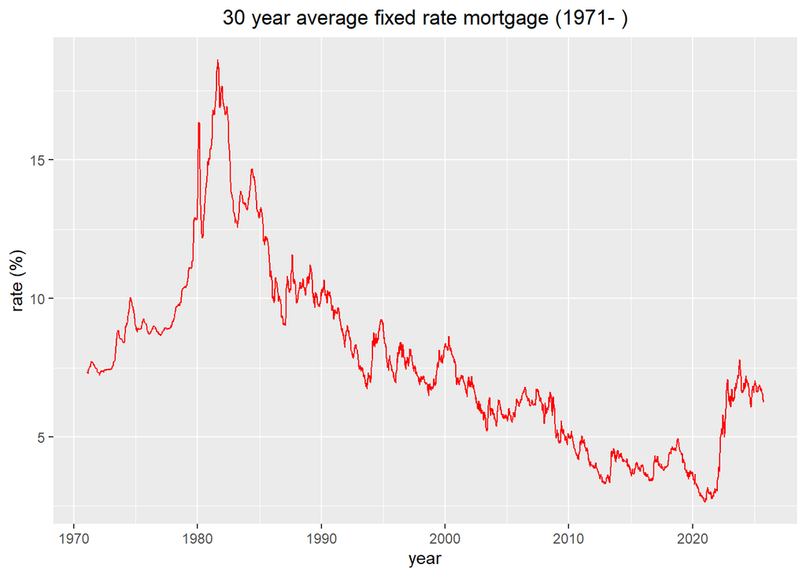

In order to build a model, we will start by looking at the sample autocorrelation function (ACF).The ACF is a graph of the average correlation of a rate with the rates at different points in time. The x-axis shows us the “lags,” so that lag 1 is the correlation between the 30 year rate at a given point in time and the 30 year rate one week before. Lag 2 is the correlation between the rate at some point and the rate two weeks before.

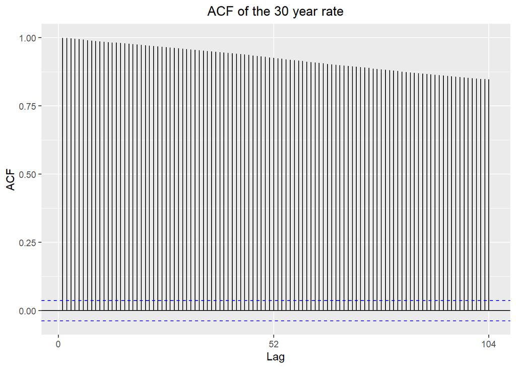

This is a problem. The ACF is very large and decays slowly. This will make forecasting difficult. Moreover, it is an indication that our time series is not “stationary.” Stationarity comes in a “strict” form and a “weak” form. Here, we are interested in weak stationarity as that will suffice for model-building. A time series is weakly stationary if it has (1) a constant mean and (2) a time-invariant autocorrelation.

This kind of ACF is an indication of non-stationarity. Now here we can tell visually that we have non-stationarity, but in other cases looks can be deceiving with data. We have a statistical test, the Augmented Dickey-Fuller (ADF) test. It essentially assumes that the time series has a “unit root” and then checks the probability that we would get this data given a unit root is present.

```
##
##  Augmented Dickey-Fuller Test
##
## data:  mtg.ts
## Dickey-Fuller = -2.3019, Lag order = 14, p-value = 0.4505
## alternative hypothesis: stationary
```

The probability is reflected in the p-value (0.4505). If our p-value is less than 0.05, we will typically reject the null hypothesis of a unit root. Here the p-value is sufficiently large that we fail to reject the null hypothesis of a unit root. Along with our graph of the sample ACF, we have good reason to transform the data in the hopes of getting a series with which we can model (while still accurately capturing the dynamics of the original series). A typical transformation is differencing, which simply takes the change between rates from week-to-week:

$$y_t = x_t - x_{t-1}$$

We will take the first difference of the series. We will then plot the new series, its ACF, and examine the results of the ADF test on it.

```
##
##  Augmented Dickey-Fuller Test
##
## data:  mtg.diff
## Dickey-Fuller = -13.086, Lag order = 14, p-value = 0.01
## alternative hypothesis: stationary
```

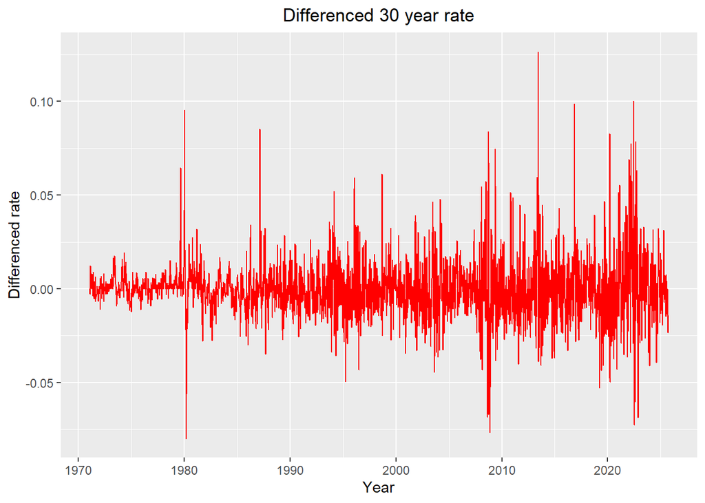

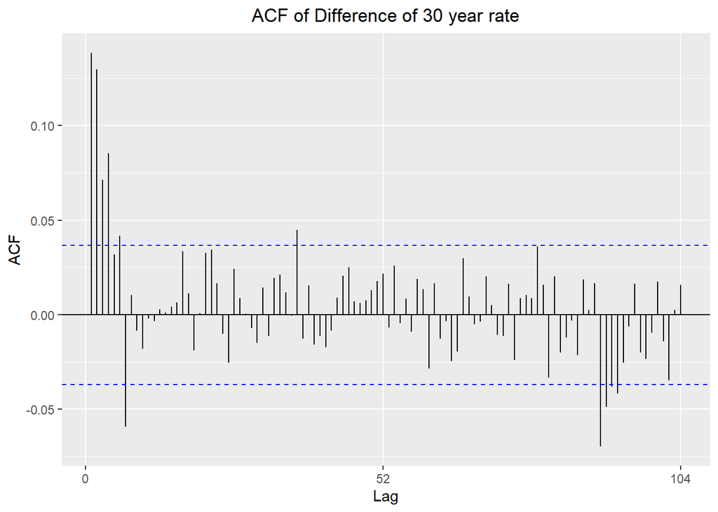

In order to help determine a model, we will also look at the sample partial autocorrelation function (PACF). It is often the case that, say, the lag-2 autocorrelation includes some of the influence of the lag-1 correlation. We sometimes want to capture the lag-2 influence with the lag-1 influence removed (or the lag-3 influence with the lag-2 and lag-1 influences removed and so on). This is what the sample PACF measures.

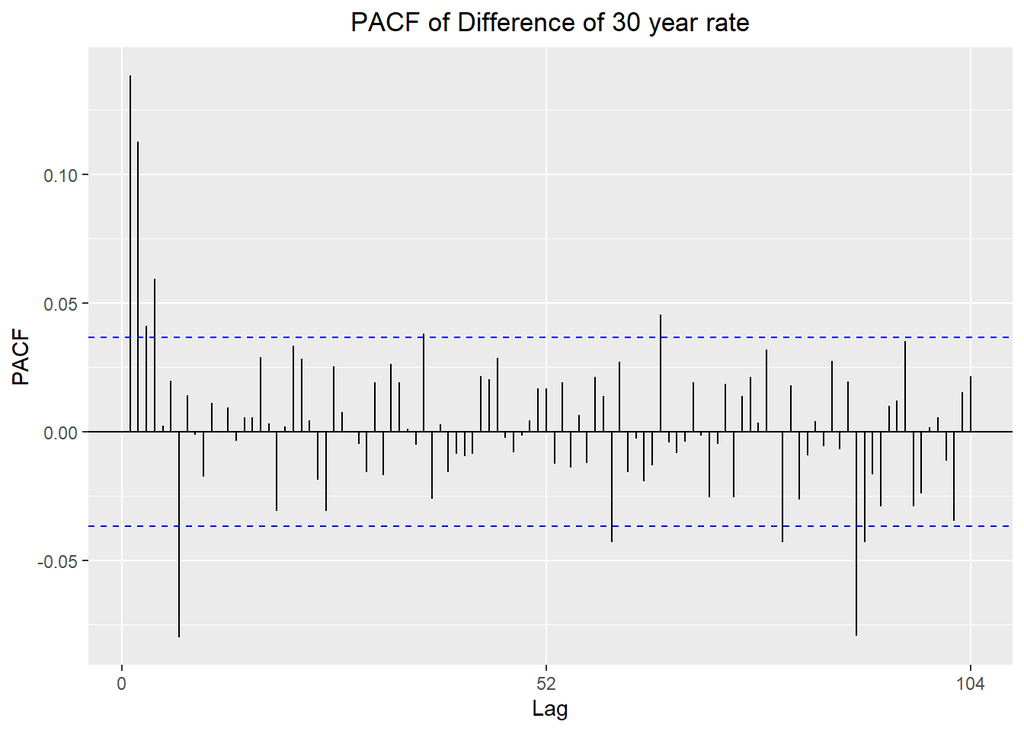

Now that we have the ACF and PACF of a stationary series, we can use them to indicate what sort of model we want to build. Both the ACF and PACF to trail off in a sinusoidal fashion, neither of them strictly “cutting off” at some lag. Moreover, neither of the series seems to have a seasonal pattern (for example, every *i*th lag being significant while the surrounding lags are insignificant). Our initial investigation does not conclusively point to either an AR(p) or an MA(q) model, so we will fit a variety of models and compare them using Akaike’s Information Criterion (AIC).

*Note: I choose AIC over BIC (Bayesian Information Critera) because we are interested here primarily in “prediction” of future rates rather than an “explanation.” BIC’s preference for more parsimonious models makes it better suited for the latter while AIC’s relative indifference to simplicity makes better suited for the former.*

|  | MA0 | MA1 | MA2 | MA3 | MA4 | MA5 | MA6 | MA7 |
| --- | --- | --- | --- | --- | --- | --- | --- | --- |
| AR0 | -15675.42 | -15718.11 | -15751.55 | -15755.70 | -15769.68 | -15770.94 | -15778.53 | -15787.16 |
| AR1 | -15728.49 | -15770.26 | -15771.20 | -15769.23 | -15772.93 | -15771.25 | -15785.39 | -15785.99 |
| AR2 | -15762.90 | -15771.19 | -15775.27 | -15773.27 | -15775.78 | -15773.90 | -15786.19 | -15783.73 |
| AR3 | -15765.75 | -15769.19 | -15773.28 | -15774.67 | -15776.75 | -15774.75 | -15784.22 | -15782.46 |
| AR4 | -15773.80 | -15771.74 | -15774.50 | -15776.66 | -15774.76 | -15772.42 | -15782.26 | -15780.51 |
| AR5 | -15771.81 | -15769.80 | -15770.85 | -15774.71 | -15772.73 | -15780.38 | -15780.31 | -15778.71 |
| AR6 | -15770.92 | -15776.59 | -15781.22 | -15781.26 | -15780.64 | -15779.39 | -15778.51 | -15776.71 |
| AR7 | -15787.00 | -15785.54 | -15783.69 | -15782.51 | -15780.55 | -15778.57 | -15776.72 | -15774.75 |

AIC is a measure of the goodness of fit of the model to the data. It is calculated by the following equation:

$$AIC = -2 * ln(likelihood) + 2 * (p + q
+ 2)$$

R obtains the maximum *log likelihood*, a measure of the probability of obtaining observed data given a choice of values for the parameters, through an iterative procedure. Since the addition of a parameter cannot decrease the log likelihood, AIC includes the second term to penalize additional parameters that do not significantly improve the model’s ability to explain the data. If an additional parameter does *nothing* to improve the model, then the AIC will increase by 2.

```
##         ar1         ar2         ma1         ma2         ma3         ma4
## -0.15348577  0.01181975  0.36484023  0.23098108  0.16780158  0.12477637
##         ma5         ma6
##  0.08463945  0.10772122
```

$$y_t = -0.153y_{t-1} + 0.012y_{t-2} +
a_t + 0.365a_{t-1} + 0.231a_{t-2} + 0.168a_{t-3} + 0.125a_{t-4} +
0.085a_{t-5} + 0.108a_{t-6}$$

The $a_t$ are i.i.d white noise and represent the error terms of the model.

*Note: when d > 0, the arima() function will not include a drift or trend term in the model because differencing should generally remove any trend. This may lead to poor predictions and we could work around this constraint in R in a few different ways, the easiest perhaps using the sarima() function from the astsa package. However, the drift term estimated by the sarima() function ends up being insignificant and the short-term forecasts are similar to those which we obtain here. For this reason, I proceed with the base R output.*

We want to make sure that our model is adequate. There are several tests that we can perform to do so. They involve examining the residuals of the model. Our model assumes the normality of the residuals. A plot of the standardized residuals should thus show that they are centered around zero with a relatively constant variance of 1 across time. The ACF of the residuals should show that they are not autocorrelated. The Box-Ljung test checks for the independence of the residuals. The null hypothesis is that the first l-lag autocorrelations are zero. A plot of the p-values of the first 20 Box-Ljung tests should show at most 1 p-value less than 0.05.

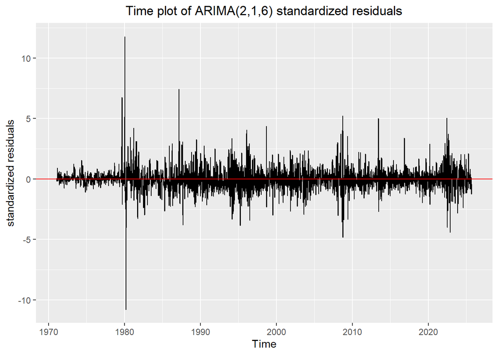

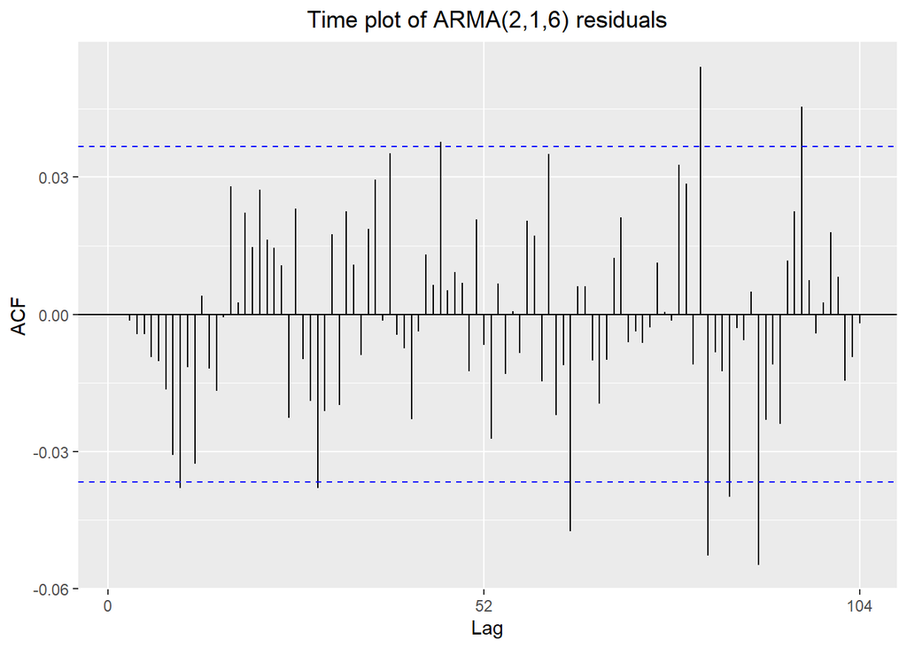

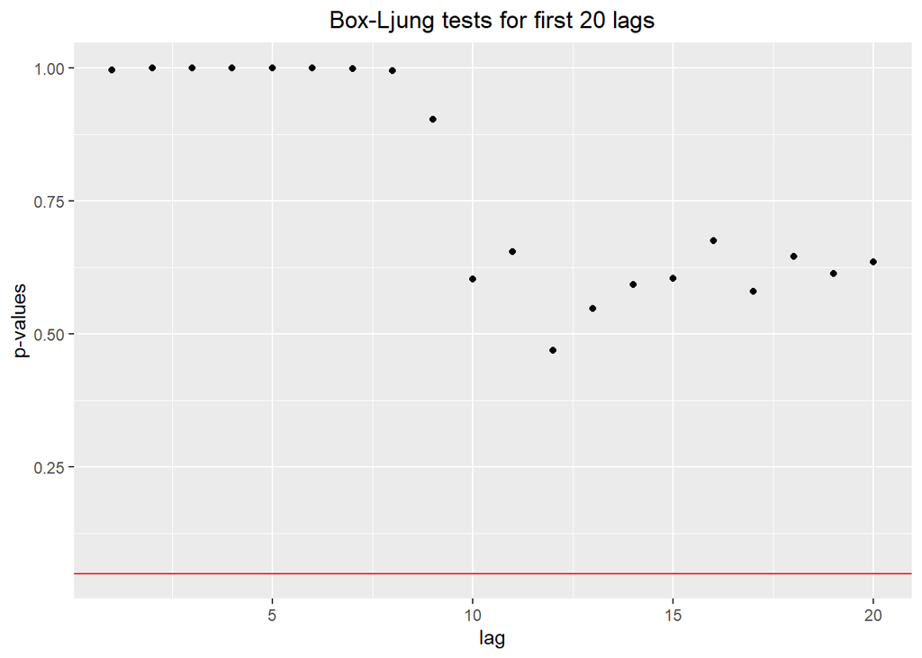

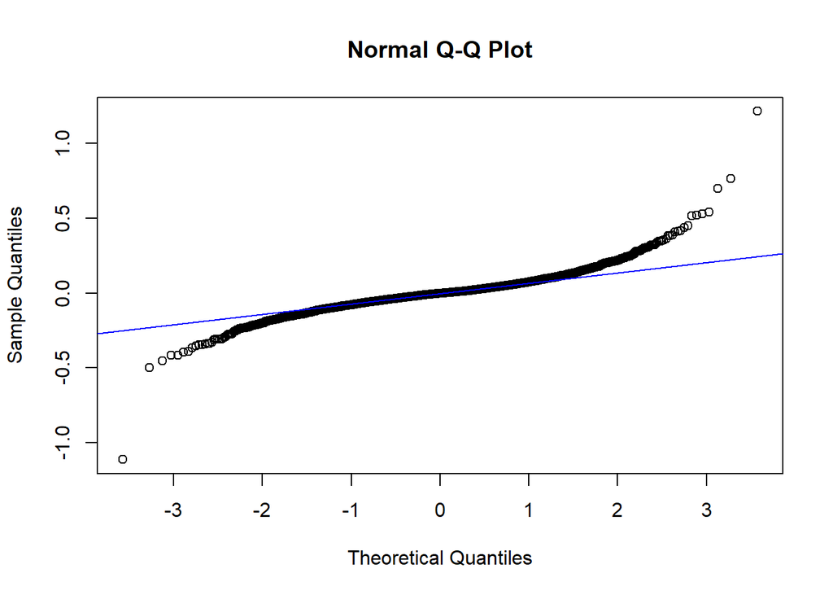

The QQ plot is a test of the normality of the residuals. The plot shows relatively fat tails, suggesting our forecast intervals may not be entirely accurate. Observing our differenced series we see a number of significant outliers, which supports the fat tails of the model residuals.

We can also look at the inverse roots of the characteristic polynomial of the ARIMA process.

```
## [1] -4.766015+0i 17.751547+0i
```

```
## [1]  1.040678+0.992820i -1.272491+0.681496i -0.161051-1.458663i
## [4] -0.161051+1.458663i -1.272491-0.681496i  1.040678-0.992820i
```

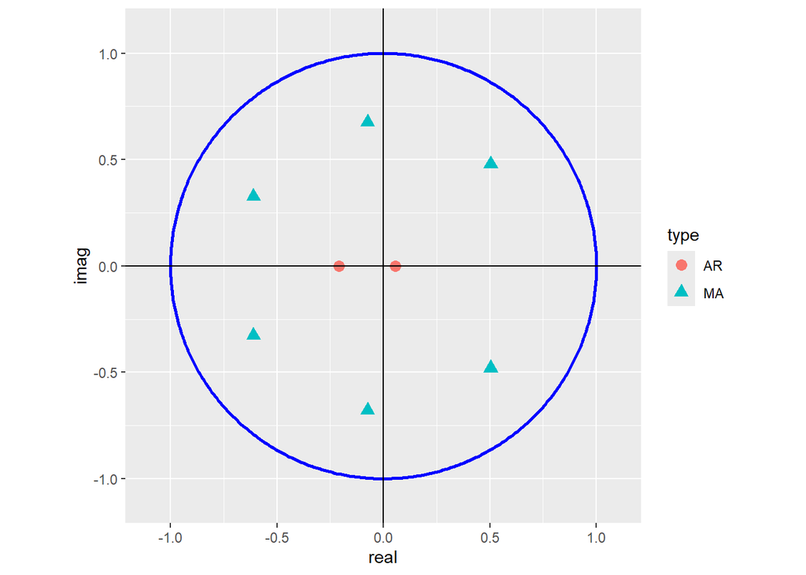

The inverse roots are all within the unit circle. This means that our process is invertible (MA roots), causal, and stationary (AR roots). We have already discussed stationarity, and its importance for accurate forecasting should be evident. Invertibility is nice because it ensures the accuracy of our parameter estimation (and thus the AIC comparisons since they depend on log likelihood). Non-invertibility means that we do not have a unique set of parameters and thus overestimation might occur. Causality simply means that present values of our series depend only on past values (and not future values).

Since our model diagnostics are reassuring, let us use the model to forecast the 30 year rate over the next four weeks.

```
##          Point Forecast    Lo 80    Hi 80    Lo 95    Hi 95
## 2025.731       6.216142 6.084106 6.348177 6.014211 6.418073
## 2025.750       6.185452 5.978052 6.392852 5.868261 6.502643
## 2025.769       6.161589 5.881852 6.441325 5.733769 6.589409
## 2025.788       6.143435 5.796069 6.490802 5.612184 6.674686
```

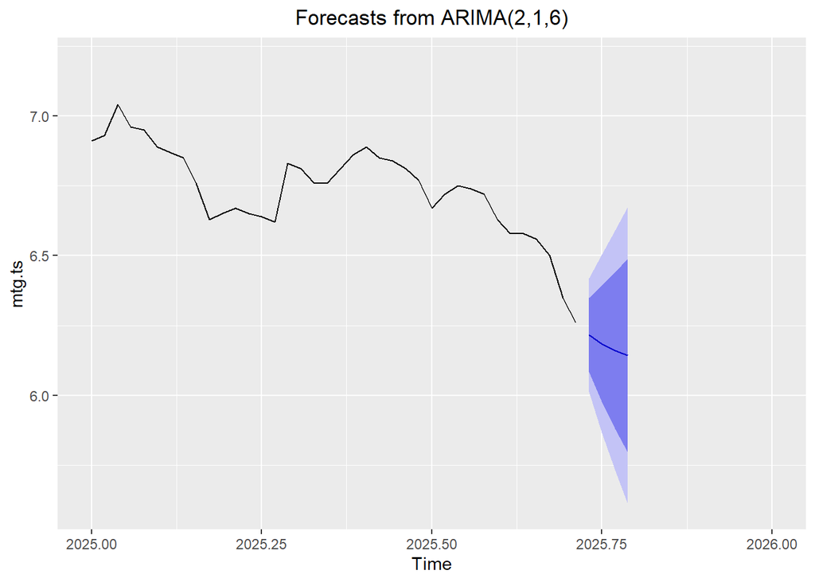

The model seems to produce plausible forecasts. When I first ran this model about two weeks ago, the most recent PMMS rate was 6.26. Since then, the rate has actually increased, first to 6.30 and then to 6.34. However, we note that both of the actual rates ended up falling within the 80% prediction intervals for their respective forecasts

Bibliography

The first few paragraphs on the PMMS come from two research notes published by Freddie Mac. The AIC table function is from Professor Ionides’ course notes on time series analysis.

Freddie Mac, “Freddie Mac’s Mortgage Rate Survey Explained” (2019), https://www.freddiemac.com/research/insight/20190614-mortgage-rate-survey-explained.

Freddie Mac, “Freddie Mac’s Newly Enhanced Mortgage Rate Survey Explained.” (2022), https://www.freddiemac.com/research/insight/20221103-freddie-macs-newly-enhanced-mortgage-rate-survey.

Ionides, Edward L. “DATASCI/STATS 531 (Winter 2024) ‘Modeling and Analysis of Time Series Data’” (Lecture, Ann Arbor, MI, 2024), https://ionides.github.io/531w24/.

Shumway, Robert H., and Stoffer, David S. *Time Series Analysis and Its Applications With R Examples.* Fourth Edition. Springer, 2016.

Tsay, Ruey S. *Analysis of Financial Time Series.* Second Edition. Hoboken, NJ: John Wiley & Sons, Inc., 2005.